# MapMet — Tumor Cell Cluster Reliability and BM vs PT Enrichment Analysis

Dr. Sara Wernig-Zorc

2026-03-28

# Overview

This document presents a complete statistical analysis of tumor cell (TC) cluster reliability and tissue-specific enrichment in the MapMet IMC dataset. The dataset comprises imaging mass cytometry (IMC) acquisitions from primary tumors (PT) and bone marrow (BM) samples across multiple timepoints from neuroblastoma patients.

The analysis addresses two central questions:

1. **Which TC cluster calls are statistically reliable**, given that some samples — particularly BM samples — contain very few TC cells? TC cluster proportions derived from small cell counts are subject to substantial multinomial sampling noise and may not reflect true biology.
2. **Are specific TC clusters genuinely enriched in BM relative to PT at diagnosis**, as claimed for marker-lo TC and early SYM-like TC cells?

The analysis proceeds in four stages: (1) bootstrap-based stability assessment of cluster calls, (2) a three-test artifact detection framework, (3) validation of flagged clusters in PT samples, and (4) formal statistical testing of BM vs PT enrichment using multiple complementary models.

# 1. Setup and Data Loading

## 1.1 Libraries and parameters

All key thresholds are defined here and propagate through the entire analysis. Adjusting these values here automatically updates all downstream results.

```r
library(tidyverse)
library(ggrepel)
library(patchwork)
library(lme4)
library(lmerTest)
library(emmeans)

set.seed(42)

# ── Data paths ─────────────────────────────────────────────────────────────────
metadata <- read.table(
  "/home/rstudio/mnt_data/MapMet/lazic.imc.2024/metadata/20231128_metadata_complete.csv",
  sep = ",", header = TRUE, row.names = 1
)
imc <- readRDS("/home/rstudio/mnt_data/MapMet/lazic.imc.2024/Rds/imc_seurat.rds")
seu_meta <- imc@meta.data

# ── Analysis parameters ────────────────────────────────────────────────────────
TC_PATTERN       <- "TC|[Tt]umor"  # regex to identify TC celltypes
BM_LABEL         <- "BM"           # tissue label for bone marrow
PT_LABEL         <- "PT"           # tissue label for primary tumor
DE_LABEL         <- "DE"           # timepoint label for diagnosis

N_BOOT           <- 1000           # bootstrap resamples per unit
MIN_TC_CELLS     <- 30             # minimum pooled TC cells for reliability flag
MAX_MEAN_SD      <- 0.10           # mean bootstrap SD threshold for instability flag

MIN_DETECT_CELLS <- 3              # minimum cells for cluster detection (T2/T3)
MIN_DETECT_PROP  <- 0.01           # minimum proportion for detection (1%)
MIN_DETECT_CELLS_T2 <- 1          # relaxed threshold for T2 presence test
CLR_PSEUDOCOUNT  <- 0.5            # Haldane-Anscombe correction before log transform

# ── Claim clusters under investigation ────────────────────────────────────────
CLAIM_CLUSTERS  <- c("CD24+ marker-lo TC", "CD24- marker-lo TC", "early SYM-like TC")
ARTIFACT_CLUSTERS <- c("CHGAhi TC", "GD2lo TC", "GATA3hi TC")

# ── Colour palette for reliability tiers ──────────────────────────────────────
rel_colours <- c(
  "critical (n<10)"   = "#E24B4A",
  "unreliable (n<30)" = "#EF9F27",
  "marginal (n<100)"  = "#BA7517",
  "reliable (n≥100)"  = "#185FA5"
)
```

## 1.2 Metadata preparation

Each cell in `seu_meta` carries a `sample_id` encoding the patient ID, tissue type, and acquisition number. The patient-level ID is extracted via regex and joined to the external metadata table to attach `Tissue` and `Timepoint` annotations.

The join is performed on both `Sample` (patient ID) and `tissue` (tissue type) simultaneously to prevent the many-to-many row explosion that occurs when a patient has samples from multiple tissues — each cell is matched only to its own tissue’s metadata entry.

```r
seu_meta <- seu_meta %>%
  mutate(Sample = str_extract(sample_id, "[0-9]{2}-[0-9]{4,5}"))

unmatched <- setdiff(unique(seu_meta$Sample), unique(metadata$Sample))
if (length(unmatched) > 0) {
  warning("Unmatched Sample IDs: ", paste(unmatched, collapse = ", "))
} else {
  message("✓ All Sample IDs match metadata (n = ", n_distinct(seu_meta$Sample), " patients)")
}

seu_meta_annot <- seu_meta %>%
  left_join(
    metadata %>%
      select(Sample, Tissue, Timepoint) %>%
      distinct(Sample, Tissue, .keep_all = TRUE),
    by = c("Sample" = "Sample", "tissue" = "Tissue")
  ) %>%
  rename(Tissue = tissue) %>%
  mutate(Timepoint = ifelse(is.na(Timepoint) & Tissue == BM_LABEL, DE_LABEL, Timepoint))

stopifnot(nrow(seu_meta_annot) == nrow(seu_meta))
message("✓ seu_meta_annot: ", nrow(seu_meta_annot), " cells | ",
        n_distinct(seu_meta_annot$Sample), " patients | ",
        n_distinct(seu_meta_annot$Tissue), " tissues")

seu_meta_annot %>%
  distinct(Sample, Tissue, Timepoint) %>%
  count(Tissue, Timepoint) %>%
  knitr::kable(caption = "Units (patient × tissue) per tissue × timepoint combination")
```

Units (patient × tissue) per tissue × timepoint combination

| Tissue | Timepoint | n |
| --- | --- | --- |
| BM |  | 26 |
| BM | DE | 48 |
| BM | RE1 | 24 |
| BM | RE2 | 36 |
| BM | REL | 13 |
| PT | DE | 25 |

# 2. TC Cluster Stability — Bootstrap Analysis

## 2.1 Rationale

IMC data from BM samples at diagnosis frequently contains very few tumor cells — in some acquisitions, fewer than 10 TC cells are identified across all ROIs. When TC cluster proportions are derived from such small counts, the resulting composition reflects multinomial sampling noise rather than true biology.

To quantify this uncertainty, I use **non-parametric bootstrap resampling**: for each patient × tissue × timepoint unit, TC cells are resampled with replacement 1,000 times, and cluster proportions are recomputed each time. The spread of these resampled proportions — measured as the bootstrap standard deviation and 95% confidence interval width — directly quantifies how reliably any given cluster proportion can be estimated from the available cell count.

The key insight is the theoretical 1/√n relationship between cell count and proportion uncertainty: with 10 TC cells, the 95% CI on a cluster at 20% spans roughly 0–55%; with 100 cells it narrows to 12–32%; with 500 cells it reaches 16–24%. Samples below ~30 TC cells are therefore treated as unreliable for composition analysis.

## 2.2 Aggregation unit definition

The analysis unit is **patient × tissue × timepoint** — all ROIs from the same patient in the same tissue at the same timepoint are pooled before bootstrapping. This reflects the true biological unit of interest and avoids pseudo-replication at the ROI level.

```r
# Identify TC clusters
tc_cols <- grep(TC_PATTERN, unique(seu_meta_annot$celltype), value = TRUE)
message("TC clusters: ", paste(tc_cols, collapse = ", "))

# Build TC-only cell table with unit IDs
tc_meta_agg <- seu_meta_annot %>%
  filter(grepl(TC_PATTERN, celltype)) %>%
  select(Sample, Tissue, Timepoint, sample_id, TC_cluster = celltype) %>%
  mutate(unit_id = paste0(Sample, " | ", Tissue, " | ", Timepoint))

# ROIs pooled per unit
rois_per_unit <- seu_meta_annot %>%
  mutate(unit_id = paste0(Sample, " | ", Tissue, " | ", Timepoint)) %>%
  distinct(unit_id, sample_id) %>%
  count(unit_id, name = "n_ROIs")

# Per-unit totals and per-cluster counts
tc_counts_agg        <- tc_meta_agg %>% count(unit_id, name = "n_TC_cells")
tc_counts_per_cluster <- tc_meta_agg %>% count(unit_id, TC_cluster, name = "n_cluster_cells")
observed_props_agg   <- tc_meta_agg %>%
  count(unit_id, TC_cluster) %>%
  group_by(unit_id) %>%
  mutate(observed_prop = n / sum(n)) %>%
  ungroup()

tc_meta_agg %>%
  distinct(unit_id, Sample, Tissue, Timepoint) %>%
  count(Tissue, Timepoint) %>%
  knitr::kable(caption = "Number of units per tissue × timepoint")
```

Number of units per tissue × timepoint

| Tissue | Timepoint | n |
| --- | --- | --- |
| BM |  | 19 |
| BM | DE | 46 |
| BM | RE1 | 20 |
| BM | RE2 | 24 |
| BM | REL | 13 |
| PT | DE | 25 |

## 2.3 Bootstrap resampling

```r
run_bootstrap_unit <- function(uid, tc_data, n_boot, all_clusters) {
  cells <- tc_data %>% filter(unit_id == uid) %>% pull(TC_cluster)
  n     <- length(cells)
  resamples <- replicate(n_boot, {
    s     <- sample(cells, size = n, replace = TRUE)
    props <- table(factor(s, levels = all_clusters)) / n
    as.numeric(props)
  })
  tibble(
    unit_id    = uid,
    TC_cluster = all_clusters,
    boot_mean  = rowMeans(resamples),
    boot_sd    = apply(resamples, 1, sd),
    boot_q025  = apply(resamples, 1, quantile, 0.025),
    boot_q975  = apply(resamples, 1, quantile, 0.975),
    boot_q25   = apply(resamples, 1, quantile, 0.25),
    boot_q75   = apply(resamples, 1, quantile, 0.75),
    n_TC_cells = n
  )
}

message("Bootstrapping ", n_distinct(tc_meta_agg$unit_id),
        " units × ", N_BOOT, " iterations...")

boot_results_agg <- map_dfr(
  unique(tc_meta_agg$unit_id),
  run_bootstrap_unit,
  tc_data      = tc_meta_agg,
  n_boot       = N_BOOT,
  all_clusters = tc_cols
)
```

## 2.4 Instability scores and flagging

Each unit receives two flags: (1) `flag_n` if fewer than 30 TC cells are pooled, and (2) `flag_sd` if the mean bootstrap SD across clusters exceeds 0.10. A unit is flagged if either criterion fires.

```r
instability_agg <- boot_results_agg %>%
  group_by(unit_id, n_TC_cells) %>%
  summarise(
    mean_boot_SD  = mean(boot_sd),
    mean_CI_width = mean(boot_q975 - boot_q025),
    max_CI_width  = max(boot_q975 - boot_q025),
    .groups = "drop"
  ) %>%
  separate(unit_id, into = c("Sample", "Tissue", "Timepoint"),
           sep = " \\| ", remove = FALSE) %>%
  left_join(rois_per_unit, by = "unit_id") %>%
  mutate(
    flag_n      = n_TC_cells < MIN_TC_CELLS,
    flag_sd     = mean_boot_SD > MAX_MEAN_SD,
    flagged     = flag_n | flag_sd,
    flag_reason = case_when(
      flag_n & flag_sd ~ paste0("n=", n_TC_cells, " & SD>", MAX_MEAN_SD),
      flag_n           ~ paste0("n=", n_TC_cells, " < ", MIN_TC_CELLS),
      flag_sd          ~ paste0("mean SD=", round(mean_boot_SD, 3)),
      TRUE             ~ "OK"
    ),
    reliability = case_when(
      n_TC_cells <  10 ~ "critical (n<10)",
      n_TC_cells <  30 ~ "unreliable (n<30)",
      n_TC_cells < 100 ~ "marginal (n<100)",
      TRUE             ~ "reliable (n≥100)"
    ) %>% factor(levels = c("critical (n<10)", "unreliable (n<30)",
                            "marginal (n<100)", "reliable (n≥100)")),
    is_BM    = Tissue    == BM_LABEL,
    is_DE    = Timepoint == DE_LABEL,
    is_BM_DE = is_BM & is_DE,
    group    = case_when(
      is_BM_DE          ~ "BM + DE",
      is_BM & !is_DE    ~ "BM, other timepoint",
      !is_BM & is_DE    ~ "Tumor + DE",
      TRUE              ~ "Tumor, other timepoint"
    ) %>% factor(levels = c("BM + DE", "BM, other timepoint",
                            "Tumor + DE", "Tumor, other timepoint"))
  )

instability_agg %>%
  count(group, reliability) %>%
  knitr::kable(caption = "Unit counts by group and reliability tier")
```

Unit counts by group and reliability tier

| group | reliability | n |
| --- | --- | --- |
| BM + DE | critical (n<10) | 9 |
| BM + DE | unreliable (n<30) | 5 |
| BM + DE | marginal (n<100) | 6 |
| BM + DE | reliable (n≥100) | 26 |
| BM, other timepoint | critical (n<10) | 42 |
| BM, other timepoint | unreliable (n<30) | 21 |
| BM, other timepoint | marginal (n<100) | 6 |
| BM, other timepoint | reliable (n≥100) | 7 |
| Tumor + DE | reliable (n≥100) | 25 |

## 2.5 Instability plot — BM+DE units highlighted

The plot below shows the key diagnostic: mean bootstrap SD (y-axis) against pooled TC cell count (x-axis, log scale) for all units. The expected 1/√n decay is visible. BM+DE units are highlighted with bold outlines; dot size reflects the number of ROIs pooled.

### All units

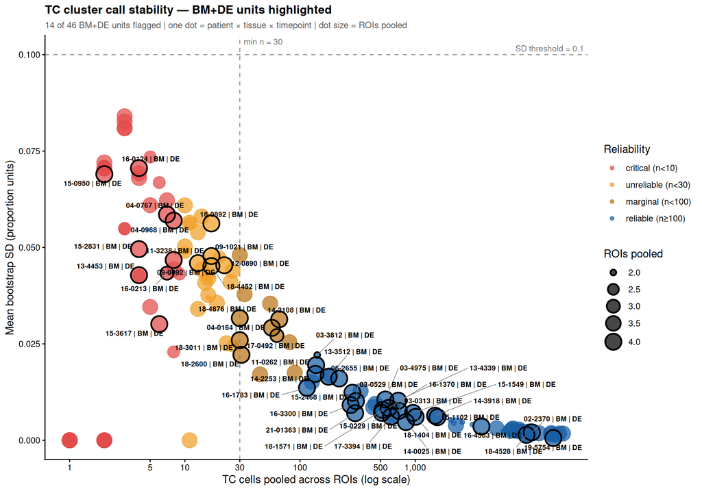

```r
bm_de_units <- instability_agg %>% filter(is_BM_DE)

p_highlighted <- ggplot(instability_agg,
                        aes(x = n_TC_cells, y = mean_boot_SD, colour = reliability)) +
  geom_vline(xintercept = MIN_TC_CELLS, linetype = "dashed",
             colour = "grey60", linewidth = 0.5) +
  geom_hline(yintercept = MAX_MEAN_SD, linetype = "dashed",
             colour = "grey60", linewidth = 0.5) +
  geom_point(aes(size = n_ROIs), alpha = 0.72) +
  geom_point(data = bm_de_units, aes(size = n_ROIs),
             shape = 21, stroke = 1.2, colour = "black", fill = NA) +
  geom_text_repel(data = bm_de_units, aes(label = unit_id),
                  size = 2.5, fontface = "bold", max.overlaps = 30,
                  box.padding = 0.4, segment.size = 0.3,
                  segment.colour = "grey50", colour = "black") +
  annotate("text", x = MIN_TC_CELLS, y = Inf,
           label = paste0("min n = ", MIN_TC_CELLS),
           hjust = -0.1, vjust = 1.5, size = 3, colour = "grey45") +
  annotate("text", x = Inf, y = MAX_MEAN_SD,
           label = paste0("SD threshold = ", MAX_MEAN_SD),
           hjust = 1.05, vjust = -0.5, size = 3, colour = "grey45") +
  scale_colour_manual(values = rel_colours, name = "Reliability") +
  scale_size_continuous(range = c(2, 7), name = "ROIs pooled") +
  scale_x_continuous(trans = "log10", breaks = c(1, 5, 10, 30, 100, 500, 1000),
                     labels = scales::comma) +
  labs(
    title    = "TC cluster call stability — BM+DE units highlighted",
    subtitle = paste0(sum(bm_de_units$flagged), " of ", nrow(bm_de_units),
                      " BM+DE units flagged | one dot = patient × tissue × timepoint | dot size = ROIs pooled"),
    x = "TC cells pooled across ROIs (log scale)",
    y = "Mean bootstrap SD (proportion units)"
  ) +
  theme_classic(base_size = 11) +
  theme(plot.title = element_text(size = 12, face = "bold", colour = "black"),
        plot.subtitle = element_text(size = 9, colour = "grey35"),
        axis.text = element_text(colour = "black"),
        legend.position = "right")

p_highlighted
```

### BM+DE bootstrap ribbons

Bootstrap confidence intervals per TC cluster for BM+DE units, sorted by ascending TC cell count. Flagged units are marked with ⚑. Wide ribbons with high uncertainty should not be interpreted biologically.

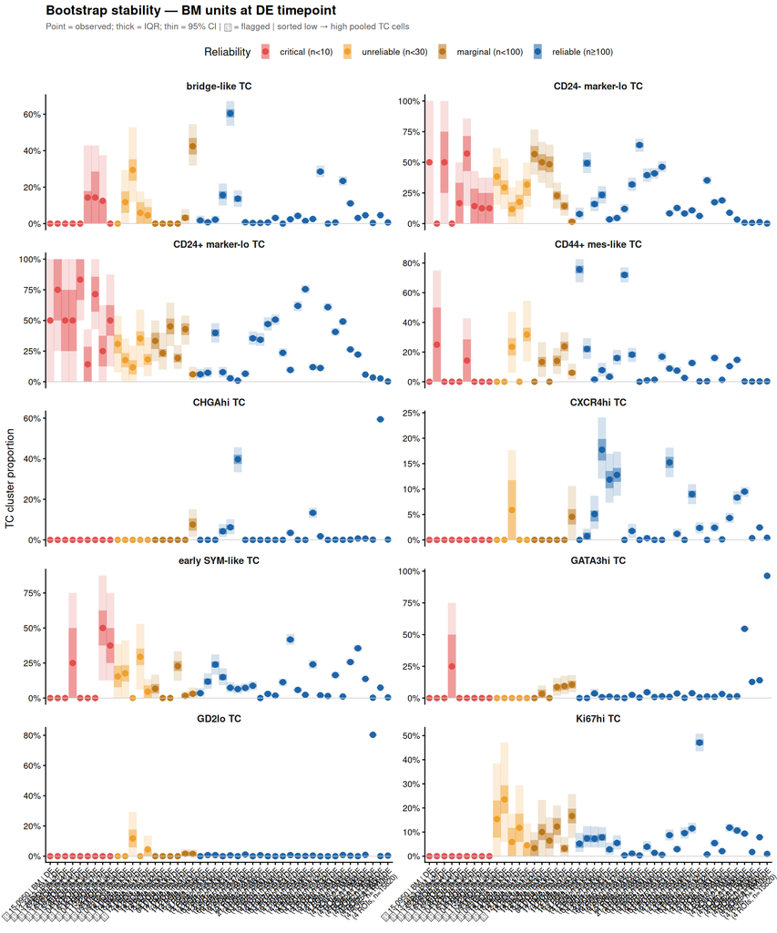

```r
bm_de_unit_ids <- bm_de_units %>% arrange(n_TC_cells) %>% pull(unit_id)

plot_df_bm_de <- boot_results_agg %>%
  filter(unit_id %in% bm_de_unit_ids) %>%
  select(-n_TC_cells) %>%
  left_join(observed_props_agg %>% select(unit_id, TC_cluster, observed_prop),
            by = c("unit_id", "TC_cluster")) %>%
  left_join(instability_agg %>% select(unit_id, flagged, reliability, n_ROIs, n_TC_cells),
            by = "unit_id") %>%
  replace_na(list(observed_prop = 0)) %>%
  mutate(
    unit_label = paste0(ifelse(flagged, "⚑ ", ""), unit_id,
                        "\n(", n_ROIs, " ROIs, n=", n_TC_cells, ")"),
    unit_label = factor(unit_label,
                        levels = unique(unit_label[order(match(unit_id, bm_de_unit_ids))]))
  )

ggplot(plot_df_bm_de, aes(x = unit_label, colour = reliability, fill = reliability)) +
  geom_linerange(aes(ymin = boot_q025, ymax = boot_q975), linewidth = 3.5, alpha = 0.18) +
  geom_linerange(aes(ymin = boot_q25, ymax = boot_q75), linewidth = 3.5, alpha = 0.45) +
  geom_point(aes(y = observed_prop), size = 2.2, alpha = 0.95) +
  geom_hline(yintercept = 0, colour = "grey80", linewidth = 0.3) +
  facet_wrap(~ TC_cluster, scales = "free_y", ncol = 2) +
  scale_colour_manual(values = rel_colours, name = "Reliability") +
  scale_fill_manual(values = rel_colours, name = "Reliability") +
  scale_y_continuous(labels = scales::percent_format(accuracy = 1)) +
  labs(title = paste0("Bootstrap stability — BM units at ", DE_LABEL, " timepoint"),
       subtitle = "Point = observed; thick = IQR; thin = 95% CI | ⚑ = flagged | sorted low → high pooled TC cells",
       x = NULL, y = "TC cluster proportion") +
  theme_classic(base_size = 10) +
  theme(plot.title = element_text(size = 12, face = "bold", colour = "black"),
        plot.subtitle = element_text(size = 8, colour = "grey35"),
        axis.text.x = element_text(angle = 45, hjust = 1, size = 7, colour = "black"),
        strip.text = element_text(face = "bold", size = 9),
        strip.background = element_blank(),
        legend.position = "top")
```

### BM+DE CI width summary

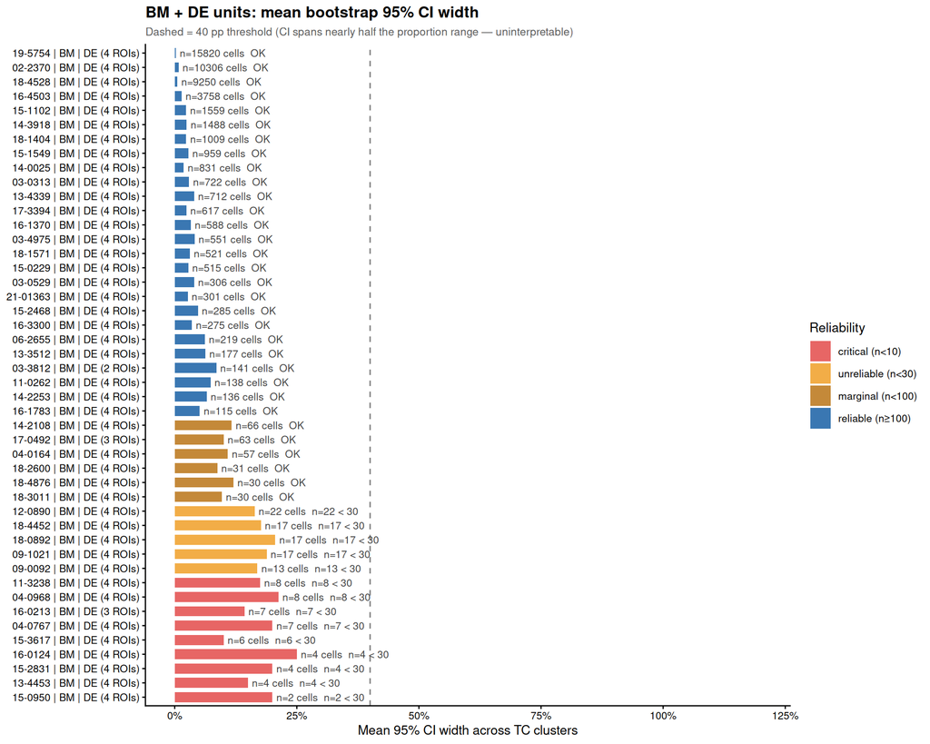

```r
p_table_order <- instability_agg %>%
  filter(is_BM_DE) %>%
  arrange(n_TC_cells) %>%
  mutate(unit_label = paste0(unit_id, " (", n_ROIs, " ROIs)")) %>%
  pull(unit_label)

instability_agg %>%
  filter(is_BM_DE) %>%
  arrange(n_TC_cells) %>%
  mutate(
    unit_label = paste0(unit_id, " (", n_ROIs, " ROIs)"),
    unit_label = factor(unit_label, levels = p_table_order)
  ) %>%
  ggplot(aes(y = unit_label)) +
  geom_col(aes(x = mean_CI_width, fill = reliability), width = 0.7, alpha = 0.85) +
  geom_vline(xintercept = 0.40, linetype = "dashed", colour = "grey50", linewidth = 0.5) +
  geom_text(aes(x = mean_CI_width + 0.008,
                label = paste0("n=", n_TC_cells, " cells  ", flag_reason)),
            hjust = 0, size = 2.8, colour = "grey25") +
  scale_fill_manual(values = rel_colours, name = "Reliability") +
  scale_x_continuous(limits = c(0, 1.2), labels = scales::percent_format(accuracy = 1)) +
  labs(title = "BM + DE units: mean bootstrap 95% CI width",
       subtitle = "Dashed = 40 pp threshold (CI spans nearly half the proportion range — uninterpretable)",
       x = "Mean 95% CI width across TC clusters", y = NULL) +
  theme_classic(base_size = 10) +
  theme(plot.title = element_text(size = 12, face = "bold", colour = "black"),
        plot.subtitle = element_text(size = 8.5, colour = "grey35"),
        axis.text = element_text(colour = "black"))
```

# 3. Artifact Detection — Three-Test Framework

The three tests below ask complementary questions about whether a TC cluster’s apparent presence in low-TC-count samples reflects biology or sampling noise. A cluster flagged by ≥2/3 tests is classified as a probable sampling artifact and excluded from BM composition analyses.

## 3.1 Test 1 — Per-cluster bootstrap instability

**Question:** Which clusters have the highest bootstrap SD overall, and is that instability concentrated in low-n units (artifact signature) or distributed across reliable units (biological variability signature)?

```r
cluster_rank <- boot_results_agg %>%
  select(-n_TC_cells) %>%
  left_join(instability_agg %>% select(unit_id, n_TC_cells), by = "unit_id") %>%
  group_by(TC_cluster) %>%
  summarise(overall_mean_SD = mean(boot_sd), overall_median_SD = median(boot_sd),
            .groups = "drop") %>%
  arrange(desc(overall_mean_SD)) %>%
  mutate(instability_rank = row_number())

cluster_instability <- boot_results_agg %>%
  select(-n_TC_cells) %>%
  left_join(instability_agg %>% select(unit_id, reliability, flagged, n_TC_cells),
            by = "unit_id") %>%
  group_by(TC_cluster, reliability) %>%
  summarise(mean_SD = mean(boot_sd), n_units = n(), .groups = "drop")

t1_cluster_order <- cluster_rank %>% arrange(overall_mean_SD) %>% pull(TC_cluster)
```

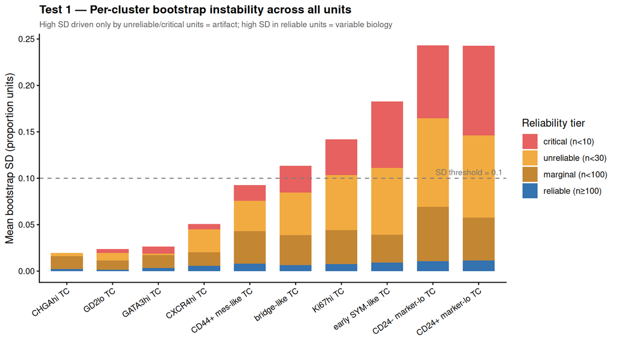

```r
cluster_instability %>%
  left_join(cluster_rank %>% select(TC_cluster, instability_rank), by = "TC_cluster") %>%
  mutate(TC_cluster = factor(TC_cluster, levels = t1_cluster_order)) %>%
  ggplot(aes(x = TC_cluster, y = mean_SD, fill = reliability)) +
  geom_col(position = "stack", width = 0.7, alpha = 0.88) +
  geom_hline(yintercept = MAX_MEAN_SD, linetype = "dashed",
             colour = "grey50", linewidth = 0.5) +
  annotate("text", x = Inf, y = MAX_MEAN_SD,
           label = paste0("SD threshold = ", MAX_MEAN_SD),
           hjust = 1.05, vjust = -0.5, size = 3, colour = "grey45") +
  scale_fill_manual(values = rel_colours, name = "Reliability tier") +
  labs(title = "Test 1 — Per-cluster bootstrap instability across all units",
       subtitle = "High SD driven only by unreliable/critical units = artifact; high SD in reliable units = variable biology",
       x = NULL, y = "Mean bootstrap SD (proportion units)") +
  theme_classic(base_size = 11) +
  theme(plot.title = element_text(size = 12, face = "bold", colour = "black"),
        plot.subtitle = element_text(size = 8.5, colour = "grey35"),
        axis.text.x = element_text(angle = 35, hjust = 1, colour = "black"),
        axis.text.y = element_text(colour = "black"))
```

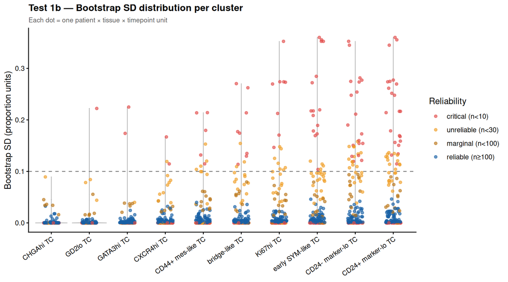

```r
boot_results_agg %>%
  select(-n_TC_cells) %>%
  left_join(instability_agg %>% select(unit_id, reliability, n_TC_cells), by = "unit_id") %>%
  mutate(TC_cluster = factor(TC_cluster, levels = t1_cluster_order)) %>%
  ggplot(aes(x = TC_cluster, y = boot_sd, colour = reliability)) +
  geom_violin(aes(group = TC_cluster), fill = "grey92", colour = "grey70",
              linewidth = 0.4, alpha = 0.6) +
  geom_jitter(width = 0.2, size = 1.4, alpha = 0.65) +
  geom_hline(yintercept = MAX_MEAN_SD, linetype = "dashed",
             colour = "grey50", linewidth = 0.5) +
  scale_colour_manual(values = rel_colours, name = "Reliability") +
  labs(title = "Test 1b — Bootstrap SD distribution per cluster",
       subtitle = "Each dot = one patient × tissue × timepoint unit",
       x = NULL, y = "Bootstrap SD (proportion units)") +
  theme_classic(base_size = 11) +
  theme(plot.title = element_text(size = 12, face = "bold", colour = "black"),
        plot.subtitle = element_text(size = 8.5, colour = "grey35"),
        axis.text.x = element_text(angle = 35, hjust = 1, colour = "black"),
        axis.text.y = element_text(colour = "black"))
```

## 3.2 Test 2 — Detection rate analysis

**Question:** Is a cluster detected more often in low-TC-count (flagged) samples than in high-TC-count (reliable) samples? A cluster that disappears as cell count increases is a phantom cluster — it exists only because with few cells, random assignment places 1–2 stray cells there by chance.

Detection here uses a relaxed threshold (≥1 cell AND ≥1% proportion) to preserve sensitivity for the enrichment-in-flagged question. The strict threshold (≥3 cells AND ≥1%) is reserved for Test 3.

```r
detection_df_t2 <- observed_props_agg %>%
  left_join(tc_counts_per_cluster, by = c("unit_id", "TC_cluster")) %>%
  replace_na(list(n_cluster_cells = 0)) %>%
  left_join(instability_agg %>% select(unit_id, n_TC_cells, flagged, reliability),
            by = "unit_id") %>%
  mutate(
    detected = n_cluster_cells >= MIN_DETECT_CELLS_T2 & observed_prop >= MIN_DETECT_PROP,
    n_bin    = cut(n_TC_cells,
                  breaks = c(0, 10, 30, 100, 500, Inf),
                  labels = c("<10", "10–30", "30–100", "100–500", ">500"),
                  right = TRUE, include.loIst = TRUE)
  )

detection_rate <- detection_df_t2 %>%
  group_by(TC_cluster, n_bin, .drop = FALSE) %>%
  summarise(n_units = n(), n_detected = sum(detected),
            detection_rate = n_detected / n_units, .groups = "drop")

artifact_cor <- detection_df_t2 %>%
  group_by(TC_cluster) %>%
  summarise(
    spearman_r             = cor(n_TC_cells, as.numeric(detected),
                                 method = "spearman", use = "complete.obs"),
    p_value                = tryCatch(
      cor.test(n_TC_cells, as.numeric(detected), method = "spearman",
               exact = FALSE)$p.value, error = function(e) NA_real_),
    pct_detected_flagged   = mean(detected[flagged == TRUE],  na.rm = TRUE) * 100,
    pct_detected_reliable  = mean(detected[flagged == FALSE], na.rm = TRUE) * 100,
    enrichment_in_flagged  = pct_detected_flagged - pct_detected_reliable,
    median_cells_when_detected = median(n_cluster_cells[detected], na.rm = TRUE),
    .groups = "drop"
  ) %>%
  mutate(
    p_adj         = p.adjust(p_value, method = "BH"),
    artifact_label = case_when(
      spearman_r < -0.3 & p_adj < 0.05 ~ "likely artifact",
      spearman_r < 0    & p_adj < 0.05 ~ "possible artifact",
      spearman_r < 0    & p_adj >= 0.05 ~ "inconclusive",
      TRUE                              ~ "likely biology"
    ) %>% factor(levels = c("likely artifact", "possible artifact",
                            "inconclusive", "likely biology"))
  ) %>%
  arrange(spearman_r)

t2_heat_order   <- artifact_cor %>% arrange(spearman_r)            %>% pull(TC_cluster)
t2_enrich_order <- artifact_cor %>% arrange(enrichment_in_flagged) %>% pull(TC_cluster)

artifact_colours <- c(
  "likely artifact"   = "#E24B4A", "possible artifact" = "#EF9F27",
  "inconclusive"      = "#888780", "likely biology"    = "#185FA5"
)
```

[figure not shown]

```r
detection_rate %>%
  left_join(artifact_cor %>% select(TC_cluster, artifact_label, spearman_r),
            by = "TC_cluster") %>%
  mutate(TC_cluster = factor(TC_cluster, levels = t2_heat_order)) %>%
  ggplot(aes(x = n_bin, y = TC_cluster, fill = detection_rate)) +
  geom_tile(colour = "white", linewidth = 0.4) +
  geom_text(aes(label = paste0(n_detected, "/", n_units)), size = 2.8, colour = "white") +
  scale_fill_gradientn(colours = c("#E6F1FB", "#378ADD", "#042C53"),
                       limits = c(0, 1), labels = scales::percent_format(accuracy = 1),
                       name = "Detection\nrate") +
  labs(title = "Test 2 — Cluster detection rate by n_TC_cells bin",
       subtitle = paste0("Detected = ≥", MIN_DETECT_CELLS_T2, " cell AND ≥",
                         MIN_DETECT_PROP * 100, "% | top rows = artifact-like"),
       x = "TC cells in unit (pooled across ROIs)", y = NULL) +
  theme_classic(base_size = 11) +
  theme(plot.title = element_text(size = 12, face = "bold", colour = "black"),
        plot.subtitle = element_text(size = 8.5, colour = "grey35"),
        axis.text = element_text(colour = "black"),
        legend.key.height = unit(0.8, "cm"))
```

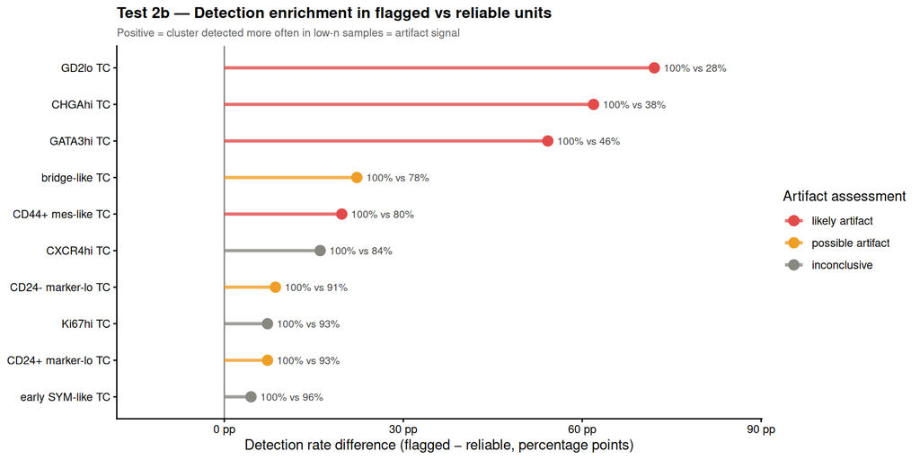

```r
artifact_cor %>%
  mutate(
    TC_cluster = factor(TC_cluster, levels = t2_enrich_order),
    hjust_val  = ifelse(enrichment_in_flagged > 0, -0.15, 1.15)
  ) %>%
  ggplot(aes(y = TC_cluster, colour = artifact_label)) +
  geom_vline(xintercept = 0, colour = "grey50", linewidth = 0.5) +
  geom_segment(aes(x = 0, xend = enrichment_in_flagged, yend = TC_cluster),
               linewidth = 1.2, alpha = 0.8) +
  geom_point(aes(x = enrichment_in_flagged), size = 3.5) +
  geom_text(aes(x = enrichment_in_flagged,
                label = paste0(round(pct_detected_flagged, 0), "% vs ",
                               round(pct_detected_reliable, 0), "%"),
                hjust = hjust_val), size = 2.8, colour = "grey25") +
  scale_colour_manual(values = artifact_colours, name = "Artifact assessment") +
  scale_x_continuous(labels = function(x) paste0(x, " pp"),
                     expand = expansion(mult = 0.25)) +
  labs(title = "Test 2b — Detection enrichment in flagged vs reliable units",
       subtitle = "Positive = cluster detected more often in low-n samples = artifact signal",
       x = "Detection rate difference (flagged − reliable, percentage points)", y = NULL) +
  theme_classic(base_size = 11) +
  theme(plot.title = element_text(size = 12, face = "bold", colour = "black"),
        plot.subtitle = element_text(size = 8.5, colour = "grey35"),
        axis.text = element_text(colour = "black"))
```

## 3.3 Test 3 — Bootstrap CI overlap with zero

**Question:** Even when a cluster is detected (using the strict ≥3 cells AND ≥1% threshold), is its bootstrap 95% CI statistically distinguishable from zero? A cluster whose CI routinely includes zero in flagged samples cannot be distinguished from complete absence — its observed proportion could easily be a sampling fluke.

```r
zero_overlap <- boot_results_agg %>%
  select(-n_TC_cells) %>%
  left_join(observed_props_agg %>% select(unit_id, TC_cluster, observed_prop),
            by = c("unit_id", "TC_cluster")) %>%
  left_join(tc_counts_per_cluster, by = c("unit_id", "TC_cluster")) %>%
  replace_na(list(observed_prop = 0, n_cluster_cells = 0)) %>%
  left_join(instability_agg %>% select(unit_id, n_TC_cells, flagged, reliability),
            by = "unit_id") %>%
  mutate(
    CI_overlaps_zero = boot_q025 <= 0,
    detected         = n_cluster_cells >= MIN_DETECT_CELLS & observed_prop >= MIN_DETECT_PROP
  )

zero_summary <- zero_overlap %>%
  filter(detected) %>%
  group_by(TC_cluster) %>%
  summarise(
    n_detected           = n(),
    pct_CI_overlaps_zero = mean(CI_overlaps_zero) * 100,
    pct_flagged_overlap  = ifelse(sum(flagged) > 0,
                                  mean(CI_overlaps_zero[flagged]) * 100, NA_real_),
    pct_reliable_overlap = ifelse(sum(!flagged) > 0,
                                  mean(CI_overlaps_zero[!flagged]) * 100, NA_real_),
    .groups = "drop"
  ) %>%
  left_join(artifact_cor %>% select(TC_cluster, artifact_label, spearman_r),
            by = "TC_cluster") %>%
  arrange(desc(pct_CI_overlaps_zero))

t3_cluster_order <- zero_summary %>% arrange(pct_CI_overlaps_zero) %>% pull(TC_cluster)
```

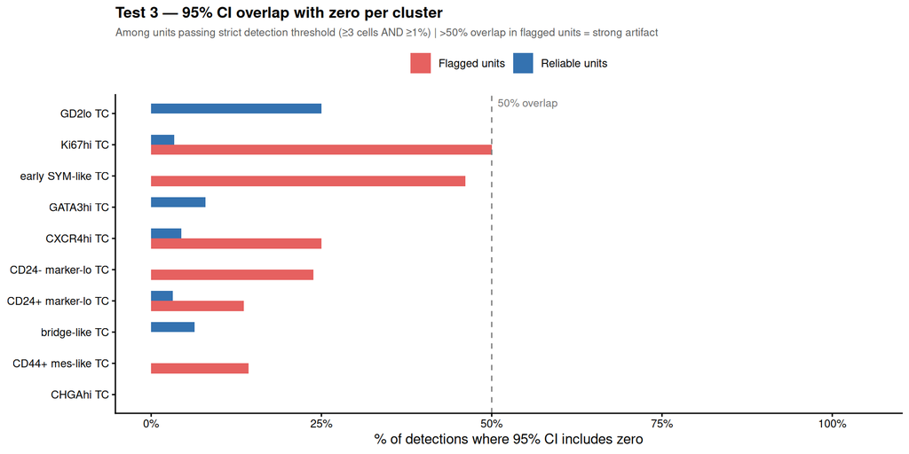

```r
zero_summary %>%
  mutate(TC_cluster = factor(TC_cluster, levels = t3_cluster_order)) %>%
  pivot_longer(cols = c(pct_flagged_overlap, pct_reliable_overlap),
               names_to = "unit_type", values_to = "pct_overlap") %>%
  mutate(unit_type = recode(unit_type,
                            pct_flagged_overlap  = "Flagged units",
                            pct_reliable_overlap = "Reliable units")) %>%
  ggplot(aes(y = TC_cluster, x = pct_overlap, fill = unit_type)) +
  geom_col(position = "dodge", width = 0.65, alpha = 0.88) +
  geom_vline(xintercept = 50, linetype = "dashed", colour = "grey50", linewidth = 0.5) +
  annotate("text", x = 50, y = Inf, label = "50% overlap",
           hjust = -0.1, vjust = 1.5, size = 3, colour = "grey45") +
  scale_fill_manual(values = c("Flagged units" = "#E24B4A", "Reliable units" = "#185FA5"),
                    name = NULL) +
  scale_x_continuous(limits = c(0, 105), labels = function(x) paste0(x, "%")) +
  labs(title = "Test 3 — 95% CI overlap with zero per cluster",
       subtitle = paste0("Among units passing strict detection threshold (≥", MIN_DETECT_CELLS,
                         " cells AND ≥", MIN_DETECT_PROP * 100,
                         "%) | >50% overlap in flagged units = strong artifact"),
       x = "% of detections where 95% CI includes zero", y = NULL) +
  theme_classic(base_size = 11) +
  theme(plot.title = element_text(size = 12, face = "bold", colour = "black"),
        plot.subtitle = element_text(size = 8.5, colour = "grey35"),
        axis.text = element_text(colour = "black"), legend.position = "top")
```

## 3.4 Combined artifact verdict

The T2* criterion corrects for a structural blind spot in T1 and T3: very rare clusters never accumulate enough cells to generate bootstrap variance (T1) or pass the strict detection threshold (T3), yet may show the strongest artifact signal in T2. T2* fires when Spearman r < −0.3 AND Δdetect > 30pp.

```r
verdict <- cluster_rank %>%
  left_join(artifact_cor %>% select(TC_cluster, spearman_r, artifact_label,
                                     enrichment_in_flagged,
                                     pct_detected_flagged, pct_detected_reliable),
            by = "TC_cluster") %>%
  left_join(zero_summary %>% select(TC_cluster, pct_CI_overlaps_zero, pct_flagged_overlap),
            by = "TC_cluster") %>%
  mutate(
    pct_flagged_overlap  = replace_na(pct_flagged_overlap, 0),
    pct_CI_overlaps_zero = replace_na(pct_CI_overlaps_zero, 0),
    t1_flag   = instability_rank <= ceiling(length(tc_cols) / 2),
    t2_flag   = artifact_label %in% c("likely artifact", "possible artifact"),
    t3_flag   = !is.na(pct_flagged_overlap) & pct_flagged_overlap > 50,
    strong_t2 = spearman_r < -0.3 & enrichment_in_flagged > 30,
    n_red_flags_revised = t1_flag + t2_flag + t3_flag + strong_t2,
    final_verdict = case_when(
      n_red_flags_revised >= 3 ~ "artifact (≥3 criteria)",
      n_red_flags_revised == 2 ~ "probable artifact (2 criteria)",
      n_red_flags_revised == 1 ~ "uncertain (1 criterion)",
      TRUE                     ~ "biology (0 criteria)"
    ) %>% factor(levels = c("artifact (≥3 criteria)", "probable artifact (2 criteria)",
                            "uncertain (1 criterion)", "biology (0 criteria)"))
  ) %>%
  arrange(desc(n_red_flags_revised))

verdict_colours <- c(
  "artifact (≥3 criteria)"         = "#E24B4A",
  "probable artifact (2 criteria)" = "#EF9F27",
  "uncertain (1 criterion)"        = "#888780",
  "biology (0 criteria)"           = "#185FA5"
)
t4_cluster_order <- verdict %>% arrange(n_red_flags_revised) %>% pull(TC_cluster)
```

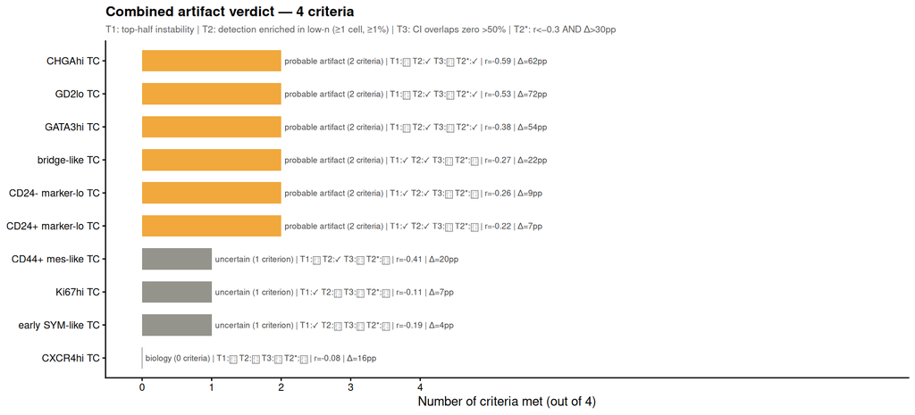

```r
verdict %>%
  mutate(TC_cluster = factor(TC_cluster, levels = t4_cluster_order)) %>%
  ggplot(aes(y = TC_cluster, x = n_red_flags_revised, fill = final_verdict)) +
  geom_col(width = 0.65, alpha = 0.9) +
  geom_text(aes(x = n_red_flags_revised + 0.05,
                label = paste0(final_verdict,
                               " | T1:", ifelse(t1_flag, "✓", "✗"),
                               " T2:", ifelse(t2_flag, "✓", "✗"),
                               " T3:", ifelse(t3_flag, "✓",
                                       ifelse(is.na(pct_flagged_overlap), "NA", "✗")),
                               " T2*:", ifelse(strong_t2, "✓", "✗"),
                               " | r=", round(spearman_r, 2),
                               " | Δ=", round(enrichment_in_flagged, 0), "pp")),
            hjust = 0, size = 2.5, colour = "grey25") +
  scale_fill_manual(values = verdict_colours, name = NULL, guide = "none") +
  scale_x_continuous(breaks = 0:4, limits = c(0, 10.5)) +
  labs(title = "Combined artifact verdict — 4 criteria",
       subtitle = "T1: top-half instability | T2: detection enriched in low-n (≥1 cell, ≥1%) | T3: CI overlaps zero >50% | T2*: r<−0.3 AND Δ>30pp",
       x = "Number of criteria met (out of 4)", y = NULL) +
  theme_classic(base_size = 11) +
  theme(plot.title = element_text(size = 12, face = "bold", colour = "black"),
        plot.subtitle = element_text(size = 8, colour = "grey35"),
        axis.text = element_text(colour = "black"))
```

```r
verdict %>%
  select(TC_cluster, instability_rank, t1_flag, t2_flag, t3_flag, strong_t2,
         spearman_r, enrichment_in_flagged, pct_CI_overlaps_zero,
         n_red_flags_revised, final_verdict) %>%
  mutate(across(where(is.numeric), ~ round(.x, 3))) %>%
  knitr::kable(caption = "Artifact verdict table — all TC clusters")
```

Artifact verdict table — all TC clusters

| TC_cluster | instability_rank | t1_flag | t2_flag | t3_flag | strong_t2 | spearman_r | enrichment_in_flagged | pct_CI_overlaps_zero | n_red_flags_revised | final_verdict |
| --- | --- | --- | --- | --- | --- | --- | --- | --- | --- | --- |
| CD24+ marker-lo TC | 1 | TRUE | TRUE | FALSE | FALSE | -0.218 | 7.246 | 5.882 | 2 | probable artifact (2 criteria) |
| CD24- marker-lo TC | 2 | TRUE | TRUE | FALSE | FALSE | -0.259 | 8.571 | 6.024 | 2 | probable artifact (2 criteria) |
| bridge-like TC | 5 | TRUE | TRUE | FALSE | FALSE | -0.273 | 22.222 | 5.769 | 2 | probable artifact (2 criteria) |
| GATA3hi TC | 8 | FALSE | TRUE | FALSE | TRUE | -0.375 | 54.237 | 8.000 | 2 | probable artifact (2 criteria) |
| GD2lo TC | 9 | FALSE | TRUE | FALSE | TRUE | -0.530 | 72.093 | 25.000 | 2 | probable artifact (2 criteria) |
| CHGAhi TC | 10 | FALSE | TRUE | FALSE | TRUE | -0.590 | 61.905 | 0.000 | 2 | probable artifact (2 criteria) |
| early SYM-like TC | 3 | TRUE | FALSE | FALSE | FALSE | -0.187 | 4.478 | 8.571 | 1 | uncertain (1 criterion) |
| Ki67hi TC | 4 | TRUE | FALSE | FALSE | FALSE | -0.107 | 7.246 | 8.955 | 1 | uncertain (1 criterion) |
| CD44+ mes-like TC | 6 | FALSE | TRUE | FALSE | FALSE | -0.413 | 19.697 | 1.786 | 1 | uncertain (1 criterion) |
| CXCR4hi TC | 7 | FALSE | FALSE | FALSE | FALSE | -0.081 | 16.071 | 6.122 | 0 | biology (0 criteria) |

# 4. Validation of Flagged Clusters in Primary Tumor

If CHGAhi, GD2lo, and GATA3hi TC are genuine cell types rather than classification noise, they should be stably detected in primary tumor samples where TC cell counts are very high (>500 cells per unit). Their near-absence in reliable BM units can then be attributed to true rarity in BM, not to sampling artifact.

## 4.1 PT detection rates for flagged clusters

```r
instability_pt <- instability_agg %>% filter(Tissue == PT_LABEL)

detection_pt <- observed_props_agg %>%
  filter(unit_id %in% instability_pt$unit_id) %>%
  left_join(tc_counts_per_cluster, by = c("unit_id", "TC_cluster")) %>%
  replace_na(list(n_cluster_cells = 0)) %>%
  left_join(instability_pt %>% select(unit_id, n_TC_cells, reliability, flagged),
            by = "unit_id") %>%
  mutate(
    detected = n_cluster_cells >= MIN_DETECT_CELLS & observed_prop >= MIN_DETECT_PROP,
    n_bin    = cut(n_TC_cells,
                  breaks = c(0, 10, 30, 100, 500, Inf),
                  labels = c("<10", "10–30", "30–100", "100–500", ">500"),
                  right = TRUE, include.loIst = TRUE)
  )

detection_rate_pt <- detection_pt %>%
  filter(TC_cluster %in% ARTIFACT_CLUSTERS) %>%
  group_by(TC_cluster, n_bin, .drop = FALSE) %>%
  summarise(n_units = n(), n_detected = sum(detected),
            detection_rate = n_detected / n_units, .groups = "drop")

artifact_cor_pt <- detection_pt %>%
  filter(TC_cluster %in% ARTIFACT_CLUSTERS) %>%
  group_by(TC_cluster) %>%
  summarise(
    spearman_r_PT            = cor(n_TC_cells, as.numeric(detected),
                                   method = "spearman", use = "complete.obs"),
    pct_detected_flagged_PT  = mean(detected[flagged == TRUE],  na.rm = TRUE) * 100,
    pct_detected_reliable_PT = mean(detected[flagged == FALSE], na.rm = TRUE) * 100,
    .groups = "drop"
  )

comparison_table <- artifact_cor_pt %>%
  left_join(
    artifact_cor %>%
      filter(TC_cluster %in% ARTIFACT_CLUSTERS) %>%
      select(TC_cluster, spearman_r_BM = spearman_r,
             pct_detected_reliable_BM = pct_detected_reliable),
    by = "TC_cluster"
  )

pt_heat_order <- detection_rate_pt %>%
  filter(n_bin == ">500") %>% arrange(desc(detection_rate)) %>% pull(TC_cluster)
pt_heat_order <- c(pt_heat_order, setdiff(ARTIFACT_CLUSTERS, pt_heat_order))
```

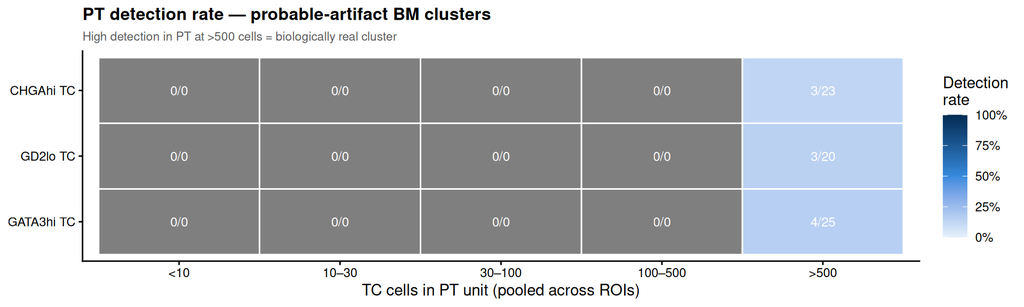

```r
detection_rate_pt %>%
  mutate(TC_cluster = factor(TC_cluster, levels = pt_heat_order)) %>%
  ggplot(aes(x = n_bin, y = TC_cluster, fill = detection_rate)) +
  geom_tile(colour = "white", linewidth = 0.5) +
  geom_text(aes(label = paste0(n_detected, "/", n_units)), size = 3.2, colour = "white") +
  scale_fill_gradientn(colours = c("#E6F1FB", "#378ADD", "#042C53"),
                       limits = c(0, 1), labels = scales::percent_format(accuracy = 1),
                       name = "Detection\nrate") +
  labs(title = "PT detection rate — probable-artifact BM clusters",
       subtitle = "High detection in PT at >500 cells = biologically real cluster",
       x = "TC cells in PT unit (pooled across ROIs)", y = NULL) +
  theme_classic(base_size = 11) +
  theme(plot.title = element_text(size = 12, face = "bold", colour = "black"),
        plot.subtitle = element_text(size = 8.5, colour = "grey35"),
        axis.text = element_text(colour = "black"))
```

## 4.2 BM vs PT detection rate comparison

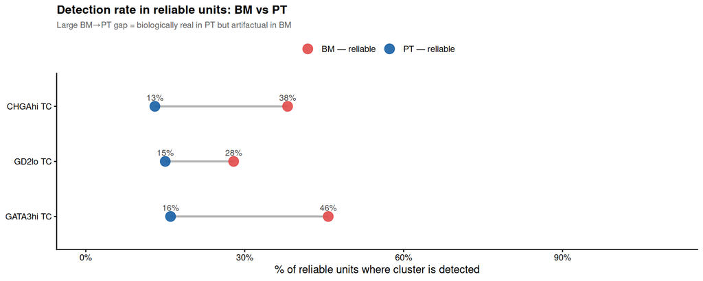

```r
comparison_table %>%
  select(TC_cluster,
         `BM — reliable` = pct_detected_reliable_BM,
         `PT — reliable` = pct_detected_reliable_PT) %>%
  pivot_longer(-TC_cluster, names_to = "context", values_to = "pct_detected") %>%
  mutate(TC_cluster = factor(TC_cluster, levels = rev(ARTIFACT_CLUSTERS))) %>%
  ggplot(aes(y = TC_cluster, x = pct_detected, colour = context)) +
  geom_line(aes(group = TC_cluster), colour = "grey70", linewidth = 1) +
  geom_point(size = 4.5, alpha = 0.9) +
  geom_text(aes(label = paste0(round(pct_detected, 0), "%")),
            vjust = -0.9, size = 3, colour = "grey25") +
  scale_colour_manual(values = c("BM — reliable" = "#E24B4A", "PT — reliable" = "#185FA5"),
                      name = NULL) +
  scale_x_continuous(limits = c(0, 110), labels = function(x) paste0(x, "%")) +
  labs(title = "Detection rate in reliable units: BM vs PT",
       subtitle = "Large BM→PT gap = biologically real in PT but artifactual in BM",
       x = "% of reliable units where cluster is detected", y = NULL) +
  theme_classic(base_size = 11) +
  theme(plot.title = element_text(size = 12, face = "bold", colour = "black"),
        plot.subtitle = element_text(size = 8.5, colour = "grey35"),
        axis.text = element_text(colour = "black"), legend.position = "top")
```

# 5. BM vs PT Enrichment — Testing the Metastasis Claim

Testing if **CD24+ marker-lo TC, CD24- marker-lo TC, and early SYM-like TC cells preferentially detach from the tumor core and metastasize to bone marrow**. I test this claim using reliable units only (n≥30 TC cells pooled), at the DE timepoint, across the mixed paired/unpaired study design.

**Important caveat:** Even if enrichment is confirmed statistically, this analysis cannot distinguish between preferential metastasis (these cells leave the tumor more readily) and preferential BM survival/expansion (all cells arrive but only these survive). The metastasis interpretation requires additional functional or longitudinal evidence.

## 5.1 Unweighted Wilcoxon tests — exploratory

```r
enrich_df <- observed_props_agg %>%
  left_join(instability_agg %>% select(unit_id, Sample, Tissue, Timepoint,
                                        n_TC_cells, flagged, reliability),
            by = "unit_id") %>%
  filter(Timepoint == DE_LABEL, !flagged) %>%
  select(Sample, Tissue, TC_cluster, observed_prop, n_TC_cells, reliability)

both_tissues <- enrich_df %>%
  distinct(Sample, Tissue) %>%
  count(Sample) %>%
  filter(n == 2) %>%
  pull(Sample)

message("Paired patients (both BM and PT reliable): ", length(both_tissues))

run_enrichment_test <- function(cluster, df, paired_samples) {
  bm <- df %>% filter(TC_cluster == cluster, Tissue == BM_LABEL)
  pt <- df %>% filter(TC_cluster == cluster, Tissue == PT_LABEL)
  bm_paired <- bm %>% filter(Sample %in% paired_samples) %>% arrange(Sample)
  pt_paired <- pt %>% filter(Sample %in% paired_samples) %>% arrange(Sample)
  unpaired_p <- tryCatch(
    wilcox.test(bm$observed_prop, pt$observed_prop, exact = FALSE)$p.value,
    error = function(e) NA_real_)
  paired_p <- tryCatch({
    if (nrow(bm_paired) >= 3 && nrow(pt_paired) >= 3 &&
        nrow(bm_paired) == nrow(pt_paired))
      wilcox.test(bm_paired$observed_prop, pt_paired$observed_prop,
                  paired = TRUE, exact = FALSE)$p.value
    else NA_real_
  }, error = function(e) NA_real_)
  med_bm <- median(bm$observed_prop, na.rm = TRUE)
  med_pt <- median(pt$observed_prop, na.rm = TRUE)
  tibble(TC_cluster = cluster, n_BM = nrow(bm), n_PT = nrow(pt),
         n_paired = nrow(bm_paired),
         median_BM_pct = med_bm * 100, median_PT_pct = med_pt * 100,
         delta_pp = (med_bm - med_pt) * 100,
         fold_BM_over_PT = ifelse(med_pt > 0, med_bm / med_pt, NA_real_),
         p_unpaired = unpaired_p, p_paired = paired_p)
}

all_clusters_enrich <- map_dfr(tc_cols, run_enrichment_test,
                                df = enrich_df, paired_samples = both_tissues) %>%
  mutate(
    p_adj_unpaired   = p.adjust(p_unpaired, method = "BH"),
    p_adj_paired     = p.adjust(p_paired,   method = "BH"),
    direction        = case_when(delta_pp > 0 ~ "BM > PT", delta_pp < 0 ~ "PT > BM",
                                 TRUE ~ "equal"),
    is_claim_cluster = TC_cluster %in% CLAIM_CLUSTERS,
    sig_label        = case_when(p_adj_unpaired < 0.001 ~ "***",
                                 p_adj_unpaired < 0.01  ~ "**",
                                 p_adj_unpaired < 0.05  ~ "*",
                                 p_adj_unpaired < 0.10  ~ "†",
                                 TRUE ~ "ns")
  ) %>%
  arrange(p_adj_unpaired)

all_clusters_enrich %>%
  select(TC_cluster, n_BM, n_PT, median_BM_pct, median_PT_pct,
         delta_pp, fold_BM_over_PT, p_adj_unpaired, sig_label, direction) %>%
  mutate(across(where(is.numeric), ~ round(.x, 3))) %>%
  knitr::kable(caption = "Unweighted Wilcoxon results — all clusters, BH-corrected")
```

Unweighted Wilcoxon results — all clusters, BH-corrected

| TC_cluster | n_BM | n_PT | median_BM_pct | median_PT_pct | delta_pp | fold_BM_over_PT | p_adj_unpaired | sig_label | direction |
| --- | --- | --- | --- | --- | --- | --- | --- | --- | --- |
| GATA3hi TC | 27 | 25 | 2.456 | 0.250 | 2.207 | 9.840 | 0.000 | *** | BM > PT |
| CD24+ marker-lo TC | 32 | 25 | 22.764 | 4.227 | 18.536 | 5.385 | 0.005 | ** | BM > PT |
| CXCR4hi TC | 20 | 25 | 3.368 | 9.966 | -6.598 | 0.338 | 0.006 | ** | PT > BM |
| GD2lo TC | 17 | 20 | 0.725 | 0.089 | 0.635 | 8.116 | 0.006 | ** | BM > PT |
| CHGAhi TC | 14 | 23 | 2.624 | 0.198 | 2.426 | 13.236 | 0.006 | ** | BM > PT |
| early SYM-like TC | 29 | 25 | 7.273 | 18.341 | -11.068 | 0.397 | 0.015 | * | PT > BM |
| Ki67hi TC | 32 | 25 | 5.451 | 9.701 | -4.250 | 0.562 | 0.015 | * | PT > BM |
| CD24- marker-lo TC | 32 | 25 | 13.520 | 4.936 | 8.584 | 2.739 | 0.015 | * | BM > PT |
| CD44+ mes-like TC | 29 | 25 | 7.801 | 19.614 | -11.812 | 0.398 | 0.099 | † | PT > BM |
| bridge-like TC | 26 | 25 | 2.803 | 4.373 | -1.569 | 0.641 | 0.672 | ns | PT > BM |

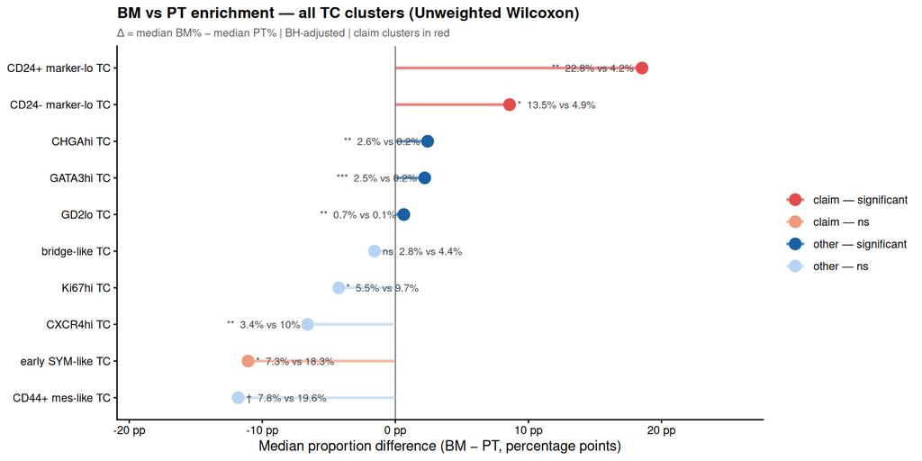

```r
forest_order <- all_clusters_enrich %>% arrange(delta_pp) %>% pull(TC_cluster)

all_clusters_enrich %>%
  mutate(
    TC_cluster   = factor(TC_cluster, levels = forest_order),
    point_colour = case_when(
      is_claim_cluster & delta_pp > 0 & p_adj_unpaired < 0.05 ~ "claim — significant",
      is_claim_cluster ~ "claim — ns",
      delta_pp > 0 & p_adj_unpaired < 0.05 ~ "other — significant",
      TRUE ~ "other — ns"
    ) %>% factor(levels = c("claim — significant", "claim — ns",
                            "other — significant", "other — ns"))
  ) %>%
  ggplot(aes(y = TC_cluster, x = delta_pp, colour = point_colour)) +
  geom_vline(xintercept = 0, colour = "grey50", linewidth = 0.5) +
  geom_segment(aes(x = 0, xend = delta_pp, yend = TC_cluster),
               linewidth = 1.0, alpha = 0.7) +
  geom_point(size = 4) +
  geom_text(aes(x = delta_pp,
                label = paste0(sig_label, "  ", round(median_BM_pct, 1),
                               "% vs ", round(median_PT_pct, 1), "%")),
            hjust = ifelse(all_clusters_enrich %>% arrange(delta_pp) %>%
                             pull(delta_pp) >= 0, -0.1, 1.1),
            size = 2.8, colour = "grey25") +
  scale_colour_manual(values = c("claim — significant" = "#E24B4A",
                                  "claim — ns" = "#F0997B",
                                  "other — significant" = "#185FA5",
                                  "other — ns" = "#B5D4F4"), name = NULL) +
  scale_x_continuous(labels = function(x) paste0(x, " pp"),
                     expand = expansion(mult = 0.3)) +
  labs(title = "BM vs PT enrichment — all TC clusters (Unweighted Wilcoxon)",
       subtitle = "Δ = median BM% − median PT% | BH-adjusted | claim clusters in red",
       x = "Median proportion difference (BM − PT, percentage points)", y = NULL) +
  theme_classic(base_size = 11) +
  theme(plot.title = element_text(size = 12, face = "bold", colour = "black"),
        plot.subtitle = element_text(size = 8.5, colour = "grey35"),
        axis.text = element_text(colour = "black"))
```

## 5.2 Linear mixed-effects models — three representations

The Unweighted Wilcoxon treats all units equally regardless of how many TC cells they contain. A unit with 15,000 cells provides a far more reliable proportion estimate than one with 30 cells. I address this with three parallel LMMs:

- **Model 1 (logit proportion):** Standard compositional model. The logit transform improves distributional properties. Zeros receive a Haldane-Anscombe correction (0.5/n) before transformation.
- **Model 2 (CLR proportion):** Centred log-ratio transform removes the sum-to-1 compositional constraint. A cluster appearing “enriched” in BM only because other clusters are depleted there will be demoted by CLR. This is the most statistically principled model.
- **Model 3 (log count):** Included for completeness only.

All models use `log(n_TC_cells)` as a weight, which gives larger/more reliable units proportionally more influence without letting the largest units dominate completely.

```r
inv_logit <- function(x) 1 / (1 + exp(-x))

reliable_de_units <- instability_agg %>%
  filter(Timepoint == DE_LABEL, !flagged) %>%
  select(unit_id, Sample, Tissue, Timepoint, n_TC_cells, flagged, reliability)

complete_grid <- expand_grid(
  unit_id    = reliable_de_units$unit_id,
  TC_cluster = tc_cols
)

base_df <- complete_grid %>%
  left_join(observed_props_agg %>% select(unit_id, TC_cluster, observed_prop),
            by = c("unit_id", "TC_cluster")) %>%
  replace_na(list(observed_prop = 0)) %>%
  left_join(tc_counts_per_cluster, by = c("unit_id", "TC_cluster")) %>%
  replace_na(list(n_cluster_cells = 0)) %>%
  left_join(reliable_de_units, by = "unit_id") %>%
  mutate(
    Tissue     = factor(Tissue, levels = c(PT_LABEL, BM_LABEL)),
    log_weight = log(n_TC_cells)
  )

message("base_df: ", nrow(base_df), " rows | ",
        n_distinct(base_df$unit_id), " units | ",
        sum(base_df$Tissue == BM_LABEL) / length(tc_cols), " BM units | ",
        sum(base_df$Tissue == PT_LABEL) / length(tc_cols), " PT units")

logit_df <- base_df %>%
  mutate(
    prop_adj   = ifelse(observed_prop == 0, CLR_PSEUDOCOUNT / n_TC_cells, observed_prop),
    logit_prop = log(prop_adj / (1 - prop_adj))
  )

clr_df <- base_df %>%
  group_by(unit_id) %>%
  mutate(
    prop_adj  = ifelse(observed_prop == 0, CLR_PSEUDOCOUNT / n_TC_cells, observed_prop),
    log_prop  = log(prop_adj),
    clr_value = log_prop - mean(log_prop)
  ) %>%
  ungroup()

clr_check <- clr_df %>% group_by(unit_id) %>%
  summarise(clr_sum = sum(clr_value), .groups = "drop")
message("CLR sanity — max |deviation from 0|: ",
        round(max(abs(clr_check$clr_sum)), 12))

count_df <- base_df %>% mutate(log_count = log1p(n_cluster_cells))
```

```r
fit_lmm_generic <- function(cluster, df, response_col,
                             weight_col = "log_weight", model_name = "model") {
  d <- df %>% filter(TC_cluster == cluster) %>%
    rename(y = all_of(response_col), w = all_of(weight_col))
  n_bm <- sum(d$Tissue == BM_LABEL, na.rm = TRUE)
  n_pt <- sum(d$Tissue == PT_LABEL, na.rm = TRUE)
  if (n_bm < 3 || n_pt < 3 || isTRUE(var(d$y, na.rm = TRUE) == 0))
    return(tibble(TC_cluster = cluster, model = model_name,
                  estimate = NA_real_, se = NA_real_, df_satt = NA_real_,
                  t_value = NA_real_, p_value = NA_real_, mm_BM = NA_real_,
                  mm_PT = NA_real_, n_BM = n_bm, n_PT = n_pt,
                  n_patients = n_distinct(d$Sample), n_paired = NA_integer_,
                  converged = FALSE, note = "insufficient data"))
  n_paired <- d %>% distinct(Sample, Tissue) %>% count(Sample) %>%
    filter(n == 2) %>% nrow()
  fit <- tryCatch(
    suppressMessages(lmer(y ~ Tissue + (1 | Sample), data = d, weights = w, REML = TRUE,
                          control = lmerControl(optimizer = "bobyqa",
                                                optCtrl = list(maxfun = 1e5)))),
    error = function(e) NULL)
  if (is.null(fit))
    return(tibble(TC_cluster = cluster, model = model_name,
                  estimate = NA_real_, se = NA_real_, df_satt = NA_real_,
                  t_value = NA_real_, p_value = NA_real_, mm_BM = NA_real_,
                  mm_PT = NA_real_, n_BM = n_bm, n_PT = n_pt,
                  n_patients = n_distinct(d$Sample), n_paired = n_paired,
                  converged = FALSE, note = "model failed"))
  conv    <- length(fit@optinfo$conv$lme4) == 0
  coef_tb <- as.data.frame(summary(fit)$coefficients)
  trow    <- paste0("Tissue", BM_LABEL)
  em <- tryCatch(as.data.frame(emmeans(fit, ~ Tissue, weights = "proportional")),
                 error = function(e) NULL)
  mm_BM <- if (!is.null(em)) em$emmean[em$Tissue == BM_LABEL] else NA_real_
  mm_PT <- if (!is.null(em)) em$emmean[em$Tissue == PT_LABEL] else NA_real_
  tibble(TC_cluster = cluster, model = model_name,
         estimate = coef_tb[trow, "Estimate"], se = coef_tb[trow, "Std. Error"],
         df_satt = coef_tb[trow, "df"], t_value = coef_tb[trow, "t value"],
         p_value = coef_tb[trow, "Pr(>|t|)"], mm_BM = mm_BM, mm_PT = mm_PT,
         n_BM = n_bm, n_PT = n_pt, n_patients = n_distinct(d$Sample),
         n_paired = n_paired, converged = conv,
         note = ifelse(conv, "OK", "convergence warning"))
}

apply_BH <- function(df) {
  df %>%
    mutate(
      p_adj_BH  = p.adjust(p_value, method = "BH"),
      sig_label = case_when(p_adj_BH < 0.001 ~ "***", p_adj_BH < 0.01  ~ "**",
                            p_adj_BH < 0.05  ~ "*",   p_adj_BH < 0.10  ~ "†",
                            TRUE ~ "ns"),
      direction = case_when(estimate > 0 ~ "BM > PT", estimate < 0 ~ "PT > BM",
                            TRUE ~ "equal"),
      is_claim  = TC_cluster %in% CLAIM_CLUSTERS
    ) %>%
    arrange(p_adj_BH)
}
```

```r
message("Fitting logit proportion model...")
results_logit <- map_dfr(tc_cols, fit_lmm_generic, df = logit_df,
                          response_col = "logit_prop", model_name = "logit_proportion") %>%
  apply_BH()

message("Fitting CLR proportion model...")
results_clr <- map_dfr(tc_cols, fit_lmm_generic, df = clr_df,
                        response_col = "clr_value", model_name = "CLR_proportion") %>%
  apply_BH()

message("Fitting log count model")
results_count <- map_dfr(tc_cols, fit_lmm_generic, df = count_df,
                          response_col = "log_count", model_name = "log_count") %>%
  apply_BH()
```

### Model results tables

#### Logit proportion

```r
results_logit %>%
  select(TC_cluster, estimate, se, df_satt, p_value, p_adj_BH,
         sig_label, direction, mm_BM, mm_PT, converged) %>%
  mutate(across(where(is.numeric), ~ round(.x, 3))) %>%
  knitr::kable(caption = "LMM results — logit(proportion) ~ Tissue + (1|Patient)")
```

LMM results — logit(proportion) ~ Tissue + (1|Patient)

| TC_cluster | estimate | se | df_satt | p_value | p_adj_BH | sig_label | direction | mm_BM | mm_PT | converged |
| --- | --- | --- | --- | --- | --- | --- | --- | --- | --- | --- |
| GATA3hi TC | 2.396 | 0.496 | 52.925 | 0.000 | 0.000 | *** | BM > PT | -3.691 | -6.086 | TRUE |
| CXCR4hi TC | -2.418 | 0.361 | 11.975 | 0.000 | 0.000 | *** | PT > BM | -4.460 | -2.042 | TRUE |
| early SYM-like TC | -1.328 | 0.380 | 51.443 | 0.001 | 0.003 | ** | PT > BM | -3.019 | -1.692 | TRUE |
| CD24+ marker-lo TC | 1.329 | 0.388 | 50.409 | 0.001 | 0.003 | ** | BM > PT | -1.638 | -2.967 | TRUE |
| Ki67hi TC | -0.924 | 0.299 | 54.498 | 0.003 | 0.006 | ** | PT > BM | -3.169 | -2.246 | TRUE |
| GD2lo TC | 1.462 | 0.488 | 32.636 | 0.005 | 0.009 | ** | BM > PT | -5.546 | -7.008 | TRUE |
| CHGAhi TC | 1.170 | 0.433 | 20.318 | 0.014 | 0.019 | * | BM > PT | -5.234 | -6.405 | TRUE |
| CD24- marker-lo TC | 0.904 | 0.373 | 28.895 | 0.022 | 0.025 | * | BM > PT | -2.016 | -2.920 | TRUE |
| CD44+ mes-like TC | -1.171 | 0.442 | 11.235 | 0.022 | 0.025 | * | PT > BM | -3.246 | -2.075 | TRUE |
| bridge-like TC | -0.104 | 0.436 | 20.849 | 0.814 | 0.814 | ns | PT > BM | -3.594 | -3.490 | TRUE |

#### CLR proportion

```r
results_clr %>%
  select(TC_cluster, estimate, se, df_satt, p_value, p_adj_BH,
         sig_label, direction, mm_BM, mm_PT, converged) %>%
  mutate(across(where(is.numeric), ~ round(.x, 3))) %>%
  knitr::kable(caption = "LMM results — CLR(proportion) ~ Tissue + (1|Patient)")
```

LMM results — CLR(proportion) ~ Tissue + (1|Patient)

| TC_cluster | estimate | se | df_satt | p_value | p_adj_BH | sig_label | direction | mm_BM | mm_PT | converged |
| --- | --- | --- | --- | --- | --- | --- | --- | --- | --- | --- |
| CXCR4hi TC | -2.301 | 0.305 | 42.545 | 0.000 | 0.000 | *** | PT > BM | -0.754 | 1.548 | TRUE |
| GATA3hi TC | 2.095 | 0.408 | 53.167 | 0.000 | 0.000 | *** | BM > PT | -0.158 | -2.253 | TRUE |
| early SYM-like TC | -1.327 | 0.286 | 50.315 | 0.000 | 0.000 | *** | PT > BM | 0.581 | 1.909 | TRUE |
| Ki67hi TC | -1.005 | 0.242 | 54.790 | 0.000 | 0.000 | *** | PT > BM | 0.482 | 1.488 | TRUE |
| CHGAhi TC | 1.067 | 0.337 | 33.059 | 0.003 | 0.007 | ** | BM > PT | -1.561 | -2.628 | TRUE |
| GD2lo TC | 1.291 | 0.408 | 23.130 | 0.004 | 0.007 | ** | BM > PT | -1.916 | -3.206 | TRUE |
| CD24+ marker-lo TC | 0.899 | 0.349 | 48.189 | 0.013 | 0.019 | * | BM > PT | 1.715 | 0.816 | TRUE |
| CD44+ mes-like TC | -1.093 | 0.429 | 25.585 | 0.017 | 0.022 | * | PT > BM | 0.311 | 1.405 | TRUE |
| CD24- marker-lo TC | 0.801 | 0.310 | 7.018 | 0.036 | 0.040 | * | BM > PT | 1.507 | 0.706 | TRUE |
| bridge-like TC | -0.423 | 0.368 | 43.924 | 0.256 | 0.256 | ns | PT > BM | -0.069 | 0.354 | TRUE |

#### Log count [confounded]

```r
results_count %>%
  select(TC_cluster, estimate, se, df_satt, p_value, p_adj_BH,
         sig_label, direction, mm_BM, mm_PT, converged) %>%
  mutate(across(where(is.numeric), ~ round(.x, 3))) %>%
  knitr::kable(caption = "LMM results — log1p(count) ~ Tissue + (1|Patient)")
```

LMM results — log1p(count) ~ Tissue + (1|Patient)

| TC_cluster | estimate | se | df_satt | p_value | p_adj_BH | sig_label | direction | mm_BM | mm_PT | converged |
| --- | --- | --- | --- | --- | --- | --- | --- | --- | --- | --- |
| early SYM-like TC | -3.460 | 0.431 | 55.000 | 0.000 | 0.000 | *** | PT > BM | 3.445 | 6.905 | FALSE |
| CXCR4hi TC | -4.641 | 0.428 | 25.483 | 0.000 | 0.000 | *** | PT > BM | 1.964 | 6.606 | TRUE |
| CD44+ mes-like TC | -3.480 | 0.412 | 45.175 | 0.000 | 0.000 | *** | PT > BM | 2.898 | 6.378 | TRUE |
| Ki67hi TC | -3.301 | 0.416 | 52.099 | 0.000 | 0.000 | *** | PT > BM | 3.178 | 6.478 | TRUE |
| CD24+ marker-lo TC | -1.506 | 0.406 | 55.000 | 0.000 | 0.001 | *** | PT > BM | 4.403 | 5.909 | FALSE |
| CHGAhi TC | -1.413 | 0.422 | 25.478 | 0.003 | 0.004 | ** | PT > BM | 1.222 | 2.635 | TRUE |
| GD2lo TC | -1.334 | 0.388 | 11.459 | 0.005 | 0.008 | ** | PT > BM | 0.890 | 2.224 | TRUE |
| CD24- marker-lo TC | -1.888 | 0.152 | 1.604 | 0.014 | 0.017 | * | PT > BM | 3.860 | 5.749 | TRUE |
| bridge-like TC | -1.932 | 0.134 | 0.676 | 0.102 | 0.114 | ns | PT > BM | 2.906 | 4.838 | TRUE |
| GATA3hi TC | -0.477 | 0.539 | 47.236 | 0.380 | 0.380 | ns | PT > BM | 2.487 | 2.965 | TRUE |

### Three-model forest comparison

Estimates are z-scored within each model to allow visual comparison across different scales. Agreement between logit and CLR (the two compositionally-corrected models) is the key diagnostic.

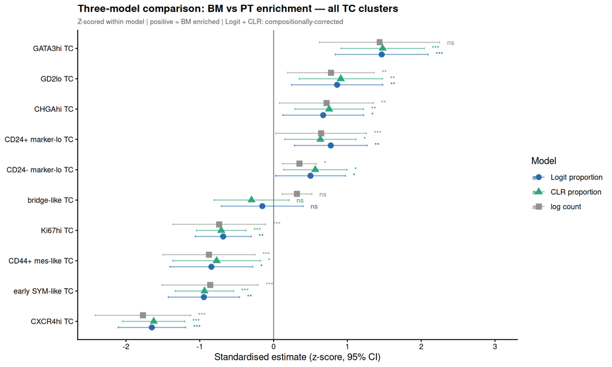

```r
all_results <- bind_rows(results_logit, results_clr, results_count) %>%
  group_by(model) %>%
  mutate(sd_est = sd(estimate, na.rm = TRUE),
         z_estimate = (estimate - mean(estimate, na.rm = TRUE)) / sd_est,
         z_se = se / sd_est,
         model_label = recode(model,
                              logit_proportion = "Logit proportion",
                              CLR_proportion   = "CLR proportion",
                              log_count        = "log count") %>%
           factor(levels = c("Logit proportion", "CLR proportion",
                              "log count"))) %>%
  ungroup()

cluster_order_forest <- results_clr %>% arrange(estimate) %>% pull(TC_cluster)
model_colours <- c("Logit proportion" = "#185FA5", "CLR proportion" = "#1D9E75",
                   "log count" = "#888780")

all_results %>%
  mutate(TC_cluster = factor(TC_cluster, levels = cluster_order_forest)) %>%
  ggplot(aes(y = TC_cluster, x = z_estimate, colour = model_label, shape = model_label)) +
  geom_vline(xintercept = 0, colour = "grey50", linewidth = 0.5) +
  geom_errorbarh(aes(xmin = z_estimate - 1.96 * z_se, xmax = z_estimate + 1.96 * z_se),
                 height = 0.2, linewidth = 0.5, alpha = 0.6,
                 position = position_dodge(width = 0.6)) +
  geom_point(size = 3, alpha = 0.9, position = position_dodge(width = 0.6)) +
  geom_text(aes(x = z_estimate + 1.96 * z_se + 0.1, label = sig_label),
            hjust = 0, size = 2.8, position = position_dodge(width = 0.6)) +
  scale_colour_manual(values = model_colours, name = "Model") +
  scale_shape_manual(values = c(16, 17, 15), name = "Model") +
  scale_x_continuous(expand = expansion(mult = c(0.05, 0.2))) +
  labs(title = "Three-model comparison: BM vs PT enrichment — all TC clusters",
       subtitle = "Z-scored within model | positive = BM enriched | Logit + CLR: compositionally-corrected",
       x = "Standardised estimate (z-score, 95% CI)", y = NULL) +
  theme_classic(base_size = 11) +
  theme(plot.title = element_text(size = 12, face = "bold", colour = "black"),
        plot.subtitle = element_text(size = 8, colour = "grey35"),
        axis.text = element_text(colour = "black"), legend.position = "right")
```

### Model agreement heatmap

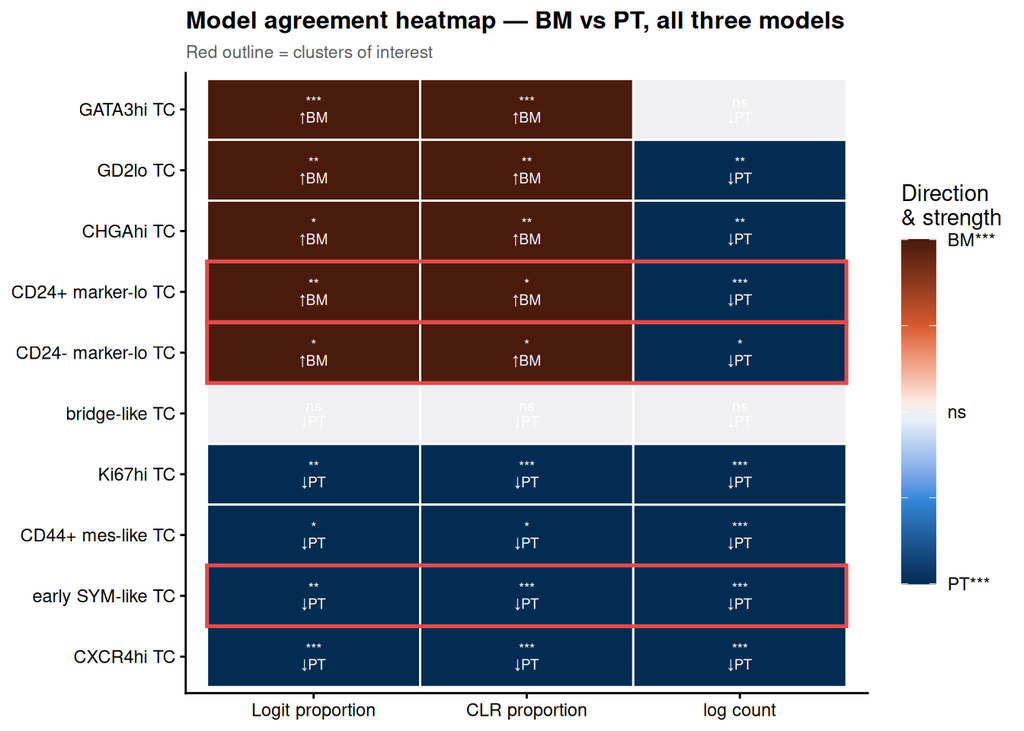

```r
sig_matrix <- all_results %>%
  mutate(
    cell_label = paste0(sig_label, "\n", ifelse(direction == "BM > PT", "↑BM", "↓PT")),
    fill_val   = case_when(
      p_adj_BH < 0.05  & direction == "BM > PT" ~  1,
      p_adj_BH < 0.05  & direction == "PT > BM" ~ -1,
      p_adj_BH < 0.10  & direction == "BM > PT" ~  0.5,
      p_adj_BH < 0.10  & direction == "PT > BM" ~ -0.5,
      TRUE ~ 0),
    TC_cluster = factor(TC_cluster, levels = cluster_order_forest)
  )

ggplot(sig_matrix, aes(x = model_label, y = TC_cluster, fill = fill_val)) +
  geom_tile(colour = "white", linewidth = 0.5) +
  geom_text(aes(label = cell_label), size = 2.5, lineheight = 0.9, colour = "white") +
  geom_rect(data = sig_matrix %>% filter(is_claim) %>%
              distinct(TC_cluster) %>% mutate(ynum = as.numeric(TC_cluster)),
            aes(ymin = ynum - 0.5, ymax = ynum + 0.5, xmin = 0.5, xmax = 3.5),
            fill = NA, colour = "#E24B4A", linewidth = 0.9, inherit.aes = FALSE) +
  scale_fill_gradientn(
    colours = c("#042C53", "#378ADD", "#E6F1FB", "#FAECE7", "#D85A30", "#4A1B0C"),
    values  = scales::rescale(c(-1, -0.5, -0.05, 0.05, 0.5, 1)),
    limits  = c(-1, 1), name = "Direction\n& strength",
    labels  = c("PT***", "", "ns", "", "BM***")) +
  labs(title = "Model agreement heatmap — BM vs PT, all three models",
       subtitle = "Red outline = clusters of interest",
       x = NULL, y = NULL) +
  theme_classic(base_size = 11) +
  theme(plot.title = element_text(size = 12, face = "bold", colour = "black"),
        plot.subtitle = element_text(size = 8.5, colour = "grey35"),
        axis.text = element_text(colour = "black"),
        legend.key.height = unit(1.2, "cm"))
```

### Claim cluster marginal means

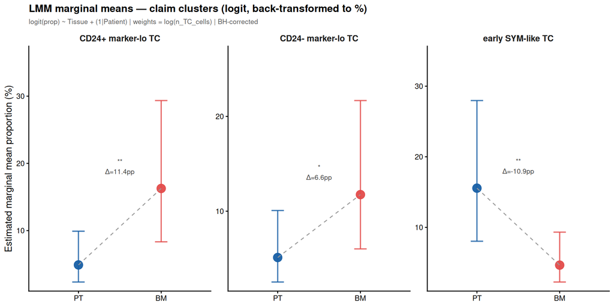

```r
claim_logit_data <- results_logit %>%
  filter(is_claim, !is.na(mm_BM), !is.na(mm_PT))

if (nrow(claim_logit_data) > 0) {
  claim_logit_mm <- claim_logit_data %>%
    pivot_longer(cols = c(mm_BM, mm_PT), names_to = "Tissue", values_to = "emmean") %>%
    mutate(
      Tissue     = recode(Tissue, mm_BM = BM_LABEL, mm_PT = PT_LABEL),
      Tissue     = factor(Tissue, levels = c(PT_LABEL, BM_LABEL)),
      prop_pct   = inv_logit(emmean) * 100,
      ci_lo      = inv_logit(emmean - 1.96 * se) * 100,
      ci_hi      = inv_logit(emmean + 1.96 * se) * 100,
      TC_cluster = factor(TC_cluster, levels = CLAIM_CLUSTERS)
    )

  sig_logit <- claim_logit_data %>%
    mutate(TC_cluster = factor(TC_cluster, levels = CLAIM_CLUSTERS),
           y_pos = inv_logit(pmax(mm_BM, mm_PT, na.rm = TRUE)) * 100 * 1.2,
           label = paste0(sig_label, "\nΔ=",
                          round(inv_logit(mm_BM) * 100 - inv_logit(mm_PT) * 100, 1), "pp"))

  ggplot(claim_logit_mm, aes(x = Tissue, y = prop_pct, colour = Tissue, fill = Tissue)) +
    geom_errorbar(aes(ymin = ci_lo, ymax = ci_hi), width = 0.15, linewidth = 0.7, alpha = 0.8) +
    geom_point(size = 4.5, alpha = 0.95) +
    geom_line(aes(group = TC_cluster), colour = "grey60", linewidth = 0.5, linetype = "dashed") +
    geom_text(data = sig_logit, aes(x = 1.5, y = y_pos, label = label),
              size = 2.8, colour = "grey25", inherit.aes = FALSE) +
    facet_wrap(~ TC_cluster, scales = "free_y", ncol = 3) +
    scale_colour_manual(values = c("BM" = "#E24B4A", "PT" = "#185FA5"), name = NULL) +
    scale_fill_manual(values = c("BM" = "#E24B4A", "PT" = "#185FA5"), name = NULL) +
    scale_y_continuous(expand = expansion(mult = c(0.05, 0.3))) +
    labs(title = "LMM marginal means — claim clusters (logit, back-transformed to %)",
         subtitle = "logit(prop) ~ Tissue + (1|Patient) | weights = log(n_TC_cells) | BH-corrected",
         x = NULL, y = "Estimated marginal mean proportion (%)") +
    theme_classic(base_size = 11) +
    theme(plot.title = element_text(size = 12, face = "bold", colour = "black"),
          plot.subtitle = element_text(size = 8, colour = "grey35"),
          strip.text = element_text(face = "bold", size = 10),
          strip.background = element_blank(),
          axis.text = element_text(colour = "black"), legend.position = "none")
} else {
  message("No convergent logit models for claim clusters — check model fitting above.")
}
```

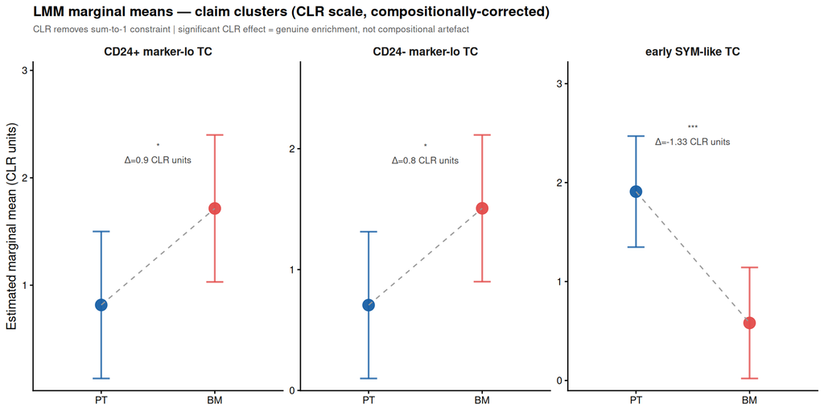

```r
claim_clr_data <- results_clr %>%
  filter(is_claim, !is.na(mm_BM), !is.na(mm_PT))

if (nrow(claim_clr_data) > 0) {
  claim_clr_mm <- claim_clr_data %>%
    pivot_longer(cols = c(mm_BM, mm_PT), names_to = "Tissue", values_to = "emmean") %>%
    mutate(
      Tissue     = recode(Tissue, mm_BM = BM_LABEL, mm_PT = PT_LABEL),
      Tissue     = factor(Tissue, levels = c(PT_LABEL, BM_LABEL)),
      prop_pct   = emmean,
      ci_lo      = emmean - 1.96 * se,
      ci_hi      = emmean + 1.96 * se,
      TC_cluster = factor(TC_cluster, levels = CLAIM_CLUSTERS)
    )

  sig_clr <- claim_clr_data %>%
    mutate(TC_cluster = factor(TC_cluster, levels = CLAIM_CLUSTERS),
           y_pos = pmax(mm_BM, mm_PT, na.rm = TRUE) * 1.3,
           label = paste0(sig_label, "\nΔ=", round(mm_BM - mm_PT, 2), " CLR units"))

  ggplot(claim_clr_mm, aes(x = Tissue, y = prop_pct, colour = Tissue, fill = Tissue)) +
    geom_errorbar(aes(ymin = ci_lo, ymax = ci_hi), width = 0.15, linewidth = 0.7, alpha = 0.8) +
    geom_point(size = 4.5, alpha = 0.95) +
    geom_line(aes(group = TC_cluster), colour = "grey60", linewidth = 0.5, linetype = "dashed") +
    geom_text(data = sig_clr, aes(x = 1.5, y = y_pos, label = label),
              size = 2.8, colour = "grey25", inherit.aes = FALSE) +
    facet_wrap(~ TC_cluster, scales = "free_y", ncol = 3) +
    scale_colour_manual(values = c("BM" = "#E24B4A", "PT" = "#185FA5"), name = NULL) +
    scale_fill_manual(values = c("BM" = "#E24B4A", "PT" = "#185FA5"), name = NULL) +
    scale_y_continuous(expand = expansion(mult = c(0.05, 0.3))) +
    labs(title = "LMM marginal means — claim clusters (CLR scale, compositionally-corrected)",
         subtitle = "CLR removes sum-to-1 constraint | significant CLR effect = genuine enrichment, not compositional artefact",
         x = NULL, y = "Estimated marginal mean (CLR units)") +
    theme_classic(base_size = 11) +
    theme(plot.title = element_text(size = 12, face = "bold", colour = "black"),
          plot.subtitle = element_text(size = 8, colour = "grey35"),
          strip.text = element_text(face = "bold", size = 10),
          strip.background = element_blank(),
          axis.text = element_text(colour = "black"), legend.position = "none")
} else {
  message("No convergent CLR models for claim clusters — check model fitting above.")
}
```